# HW3

Sarah Zhou

11/9/2015

**Part 1: Sampling distribution of the sample proportion**

Loading the libraries

```r
library(dplyr)
```

```r
library(ggplot2)
library(stringr)
library(GGally)
```

1. Loading dataset

```r
pops <- read.csv("https://stat.duke.edu/~mc301/data/cat_pops.csv")
```

2 and 3. Creating sampling distributions and describing their shape

```r
sampling <- function(data = NULL, nsample = NULL, seed = NULL,
                     n_sim = NULL, success = NULL) {
  set.seed(seed)
  pop_data <- data.frame(sample_prop_success = rep(NA, n_sim))

  for (i in 1:n_sim) {
    sim <- sample(data, size = nsample, replace = TRUE)
    samp_prop_success <- sum(sim == success)/length(sim)
    pop_data$sample_prop_success[i] <- samp_prop_success
  }

  histogram <- ggplot(pop_data,aes(x = sample_prop_success)) +
    geom_histogram() +
    ggtitle(paste("Sampling Distribution of Sample Size",nsample))

  norm_prob_plot <- ggplot(data = pop_data,aes(sample = sample_prop_success)) +
    geom_point(stat = "qq") +
    ggtitle(paste("Normal Probability Plot of Sample Size",nsample))

  summary <- pop_data %>%
    summarise(mean = mean(sample_prop_success), median = median(sample_prop_success),
              sd = sd(sample_prop_success))

  print(histogram)
  print(norm_prob_plot)
  return(summary)
}
```

*For very low success rate data*

```r
sampling(data = pops$p_very_low, nsample = 10, seed = 3948, n_sim = 15000,
         success = "success")
```

```
## stat_bin: binwidth defaulted to range/30. Use 'binwidth = x' to adjust this.
```

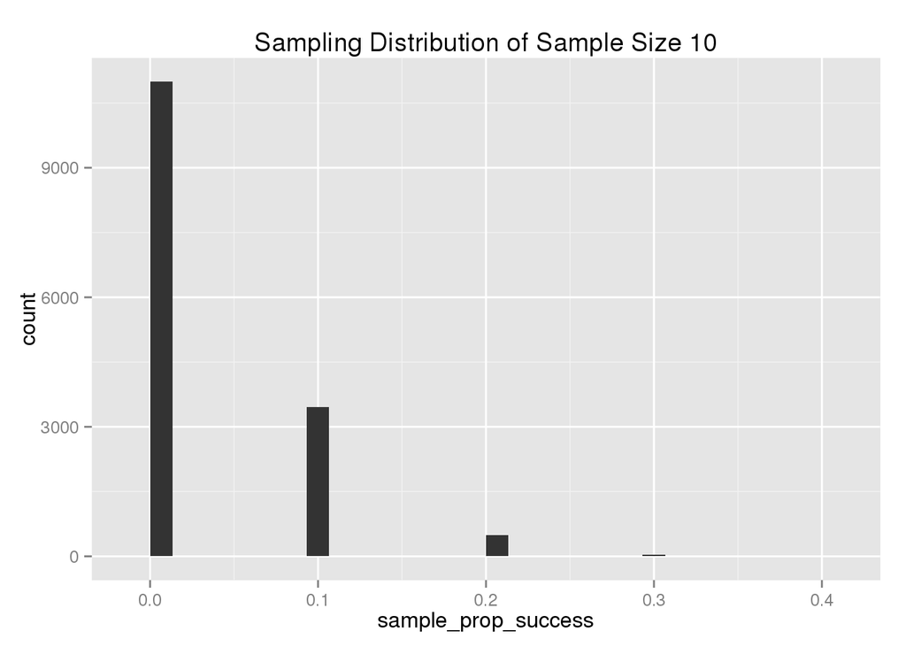

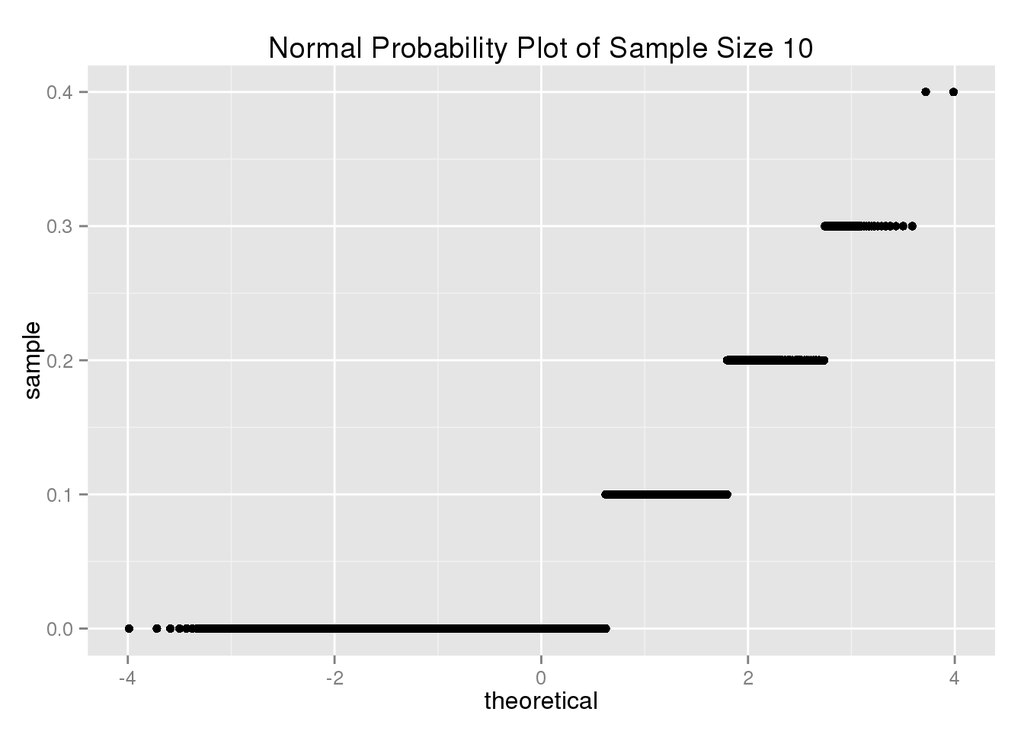

```
##     mean median         sd
## 1 0.0306      0 0.05456347
```

```r
sampling(data = pops$p_very_low, nsample = 50, seed = 3348, n_sim = 15000,
         success = "success")
```

```
## stat_bin: binwidth defaulted to range/30. Use 'binwidth = x' to adjust this.
```

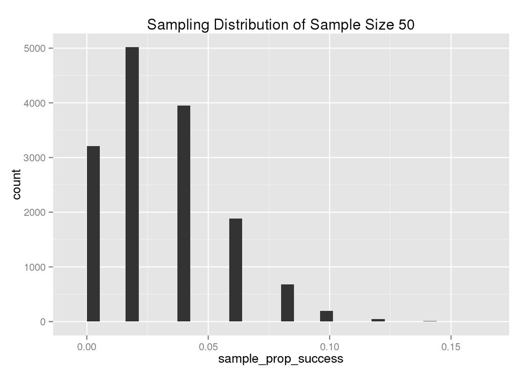

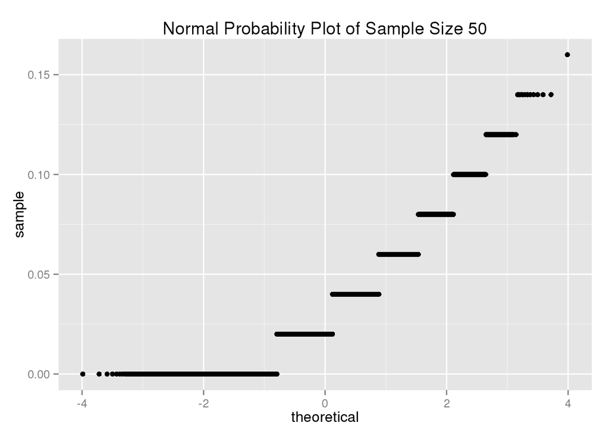

```
##         mean median         sd
## 1 0.03021467   0.02 0.02407307
```

```r
sampling(data = pops$p_very_low, nsample = 200, seed = 3647, n_sim = 15000,
         success = "success")
```

```
## stat_bin: binwidth defaulted to range/30. Use 'binwidth = x' to adjust this.
```

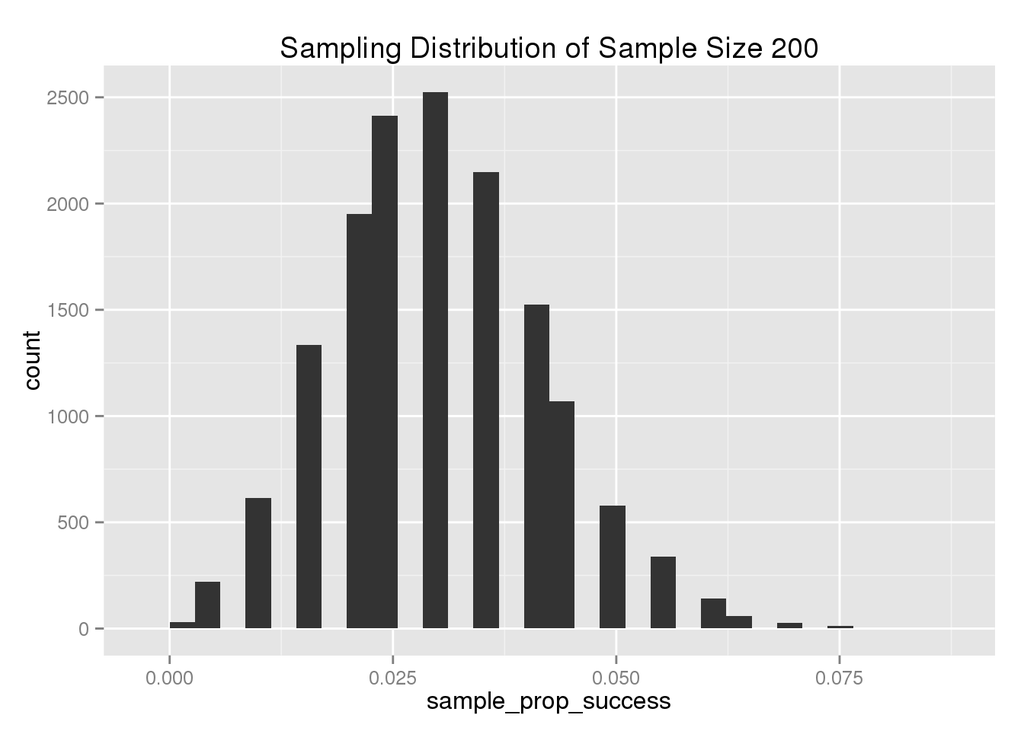

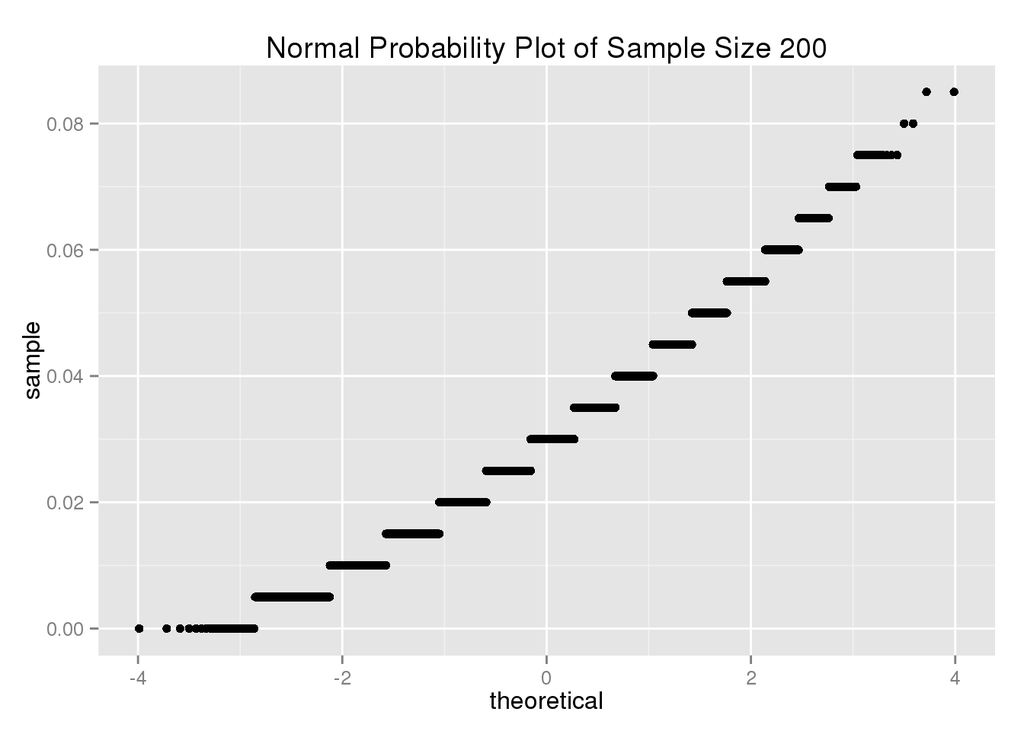

```
##         mean median         sd
## 1 0.02998833   0.03 0.01194268
```

*For low success rate data*

```r
sampling(data = pops$p_low, nsample = 10, seed = 3487, n_sim = 15000, success = "success")
```

```
## stat_bin: binwidth defaulted to range/30. Use 'binwidth = x' to adjust this.
```

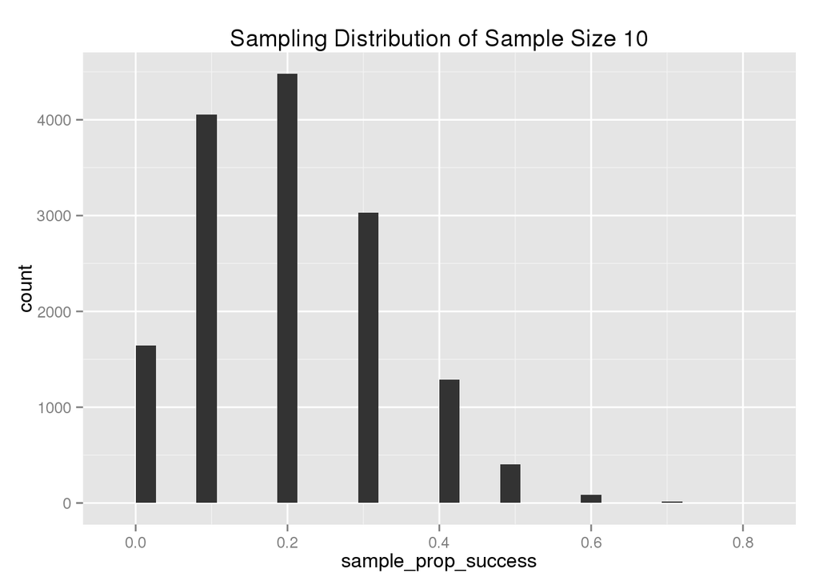

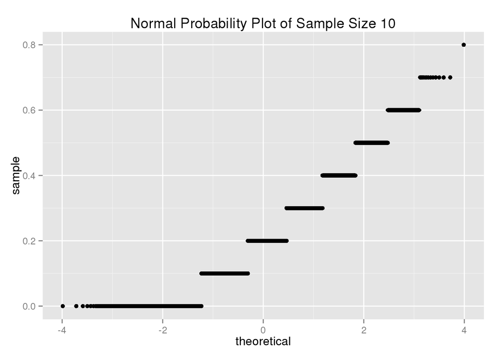

```
##      mean median        sd
## 1 0.19924    0.2 0.1268562
```

```r
sampling(data = pops$p_low, nsample = 50, seed = 3797, n_sim = 15000, success = "success")
```

```
## stat_bin: binwidth defaulted to range/30. Use 'binwidth = x' to adjust this.
```

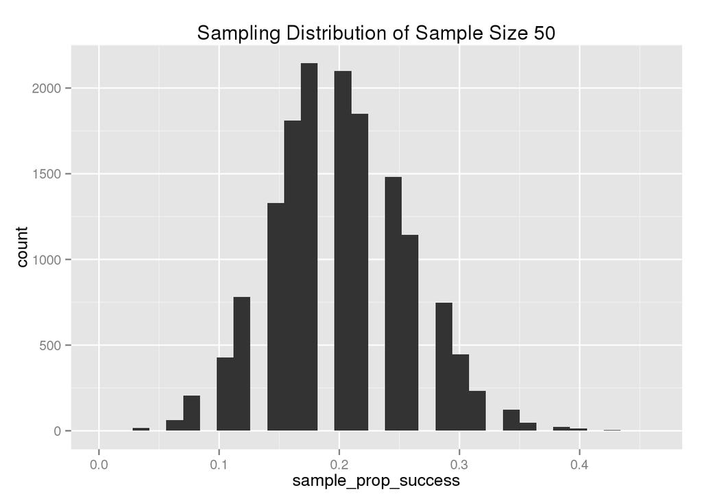

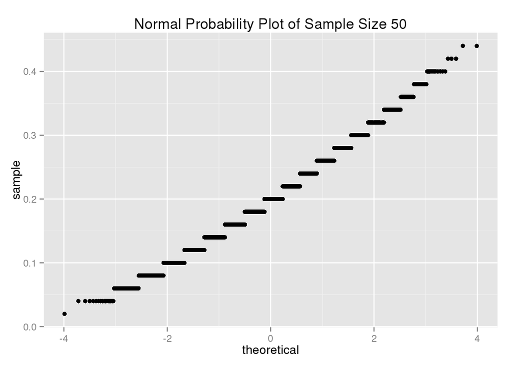

```
##       mean median         sd
## 1 0.199572    0.2 0.05627884
```

```r
sampling(data = pops$p_low, nsample = 200, seed = 3687, n_sim = 15000, success = "success")
```

```
## stat_bin: binwidth defaulted to range/30. Use 'binwidth = x' to adjust this.
```

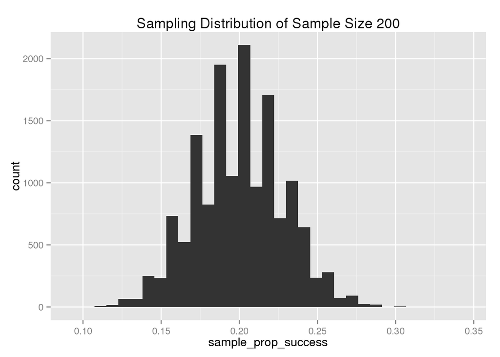

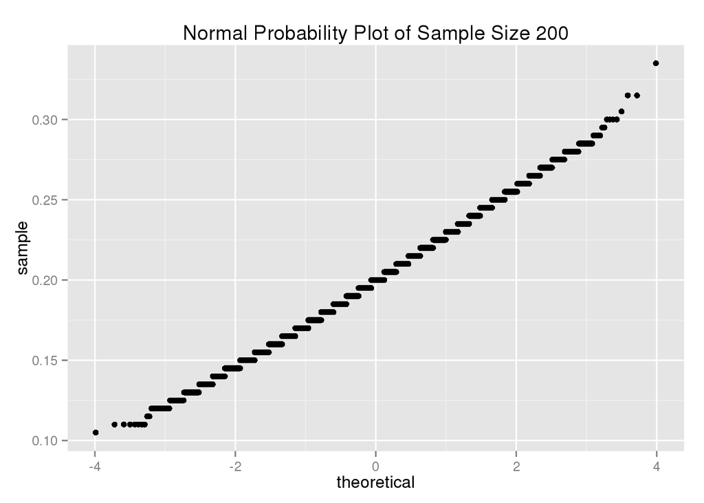

```
##      mean median         sd
## 1 0.19975    0.2 0.02808321
```

*For medium success rate data*

```r
sampling(data = pops$p_med, nsample = 10, seed = 3417, n_sim = 15000, success = "success")
```

```
## stat_bin: binwidth defaulted to range/30. Use 'binwidth = x' to adjust this.
```

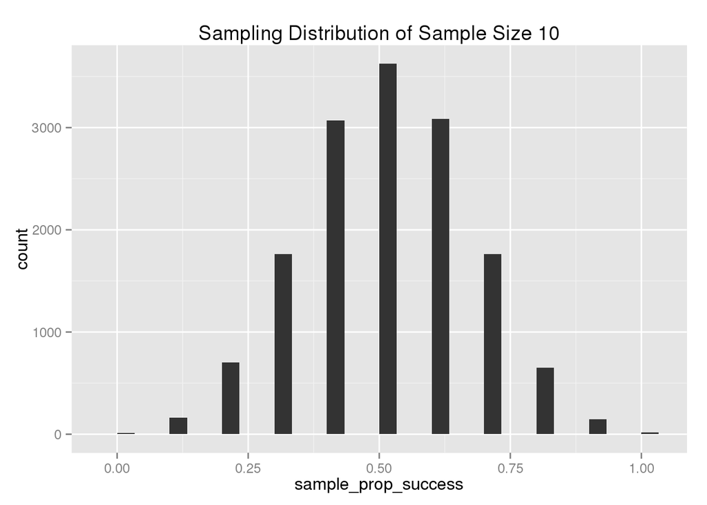

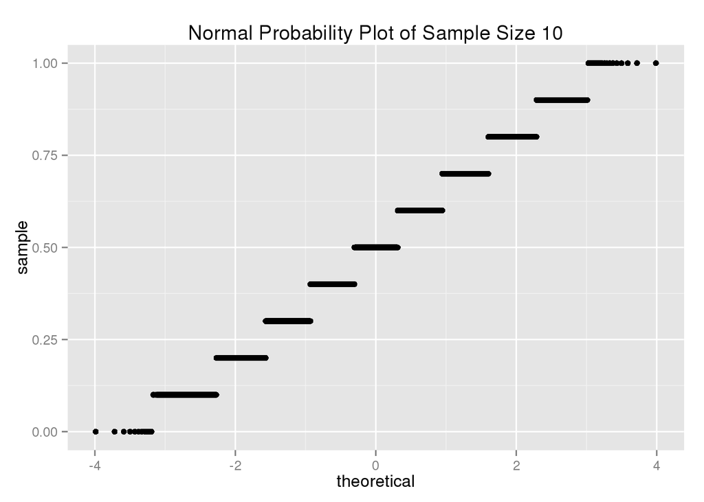

[output not shown]

```r
sampling(data = pops$p_med, nsample = 50, seed = 3410, n_sim = 15000, success = "success")
```

```
## stat_bin: binwidth defaulted to range/30. Use 'binwidth = x' to adjust this.
```

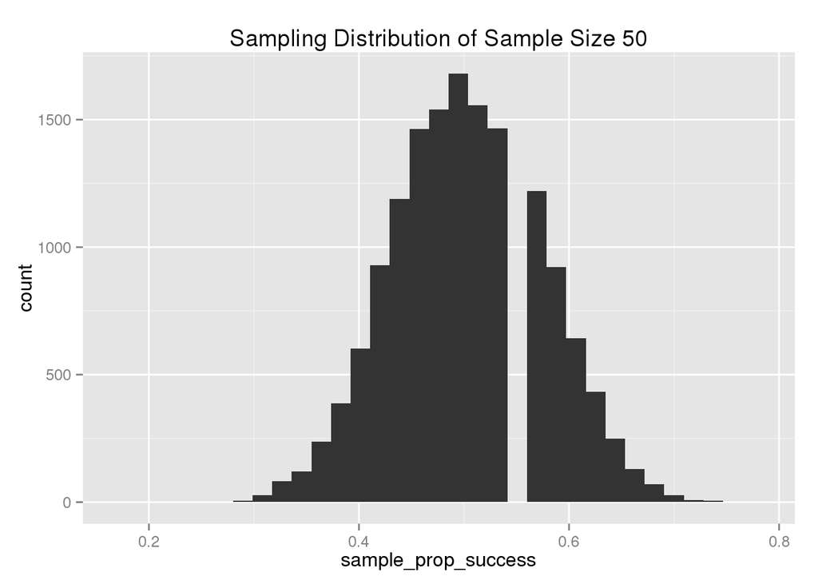

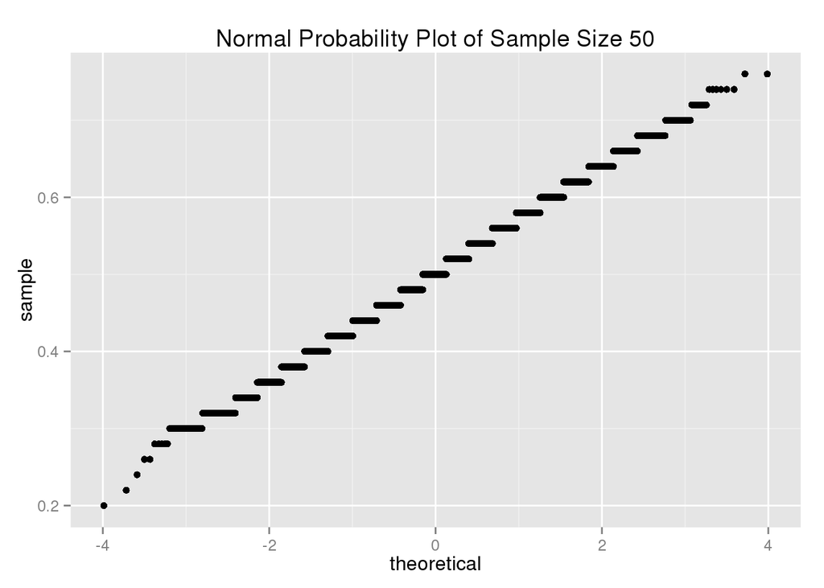

```
##        mean median         sd
## 1 0.5008787    0.5 0.07083287
```

```r
sampling(data = pops$p_med, nsample = 200, seed = 2417, n_sim = 15000, success = "success")
```

```
## stat_bin: binwidth defaulted to range/30. Use 'binwidth = x' to adjust this.
```

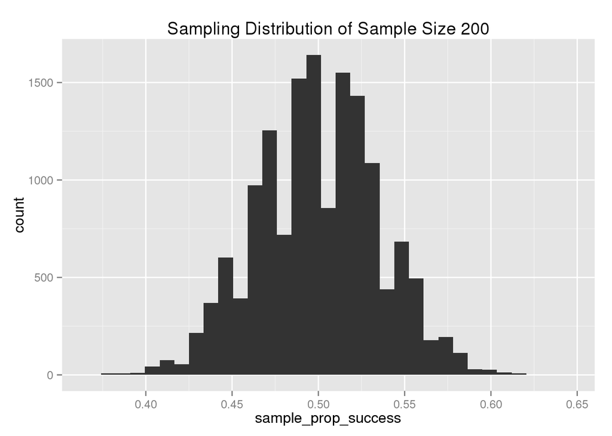

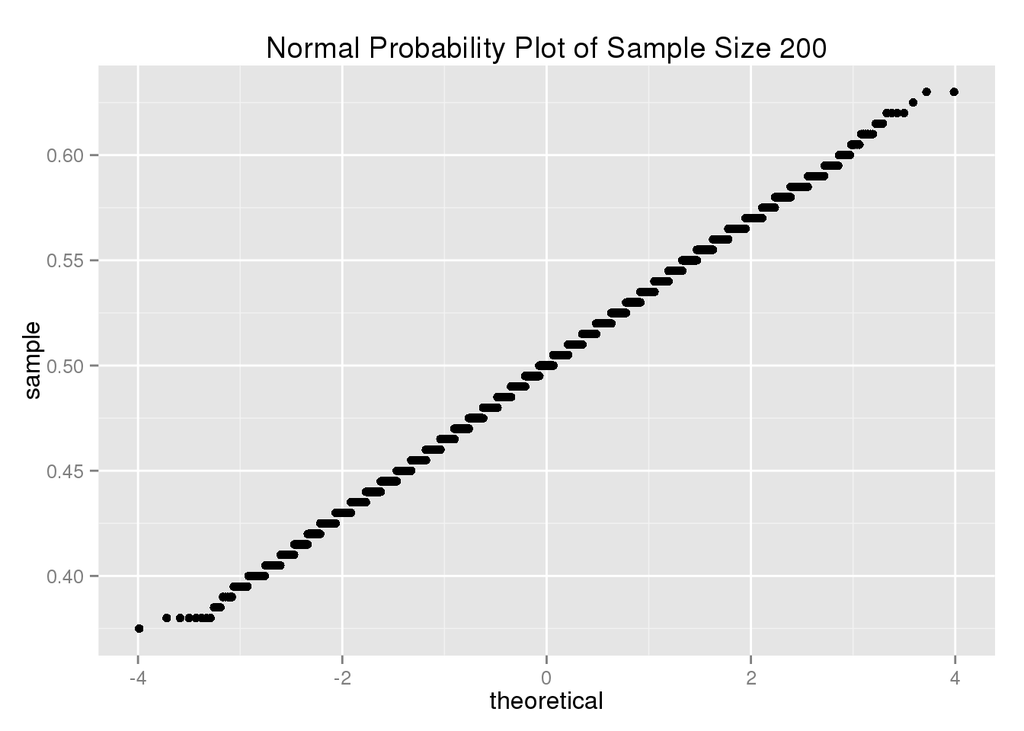

```
##        mean median         sd
## 1 0.4998447    0.5 0.03543124
```

*For high success rate data*

```r
sampling(data = pops$p_high, nsample = 10, seed = 3418, n_sim = 15000, success = "success")
```

```
## stat_bin: binwidth defaulted to range/30. Use 'binwidth = x' to adjust this.
```

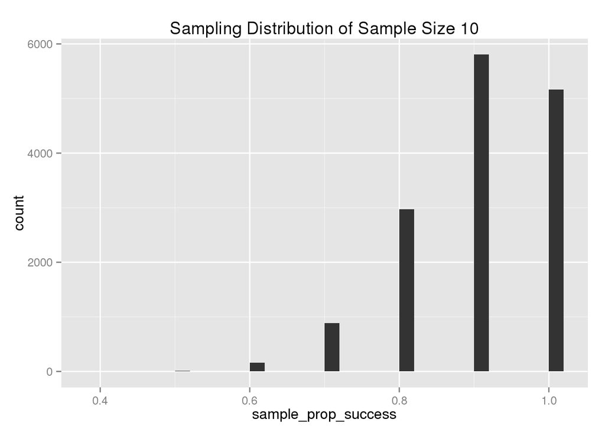

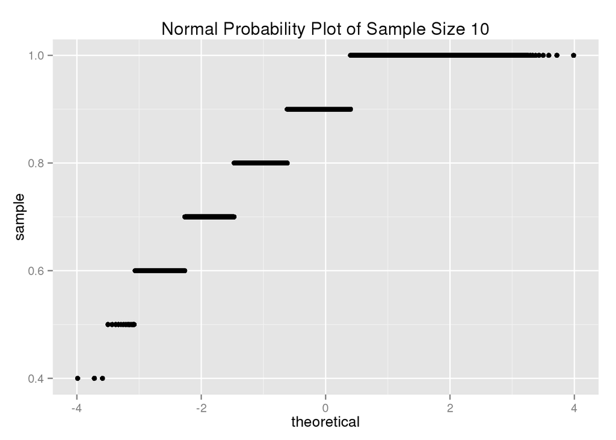

```
##     mean median        sd
## 1 0.8992    0.9 0.0944808
```

```r
sampling(data = pops$p_high, nsample = 50, seed = 3430, n_sim = 15000, success = "success")
```

```
## stat_bin: binwidth defaulted to range/30. Use 'binwidth = x' to adjust this.
```

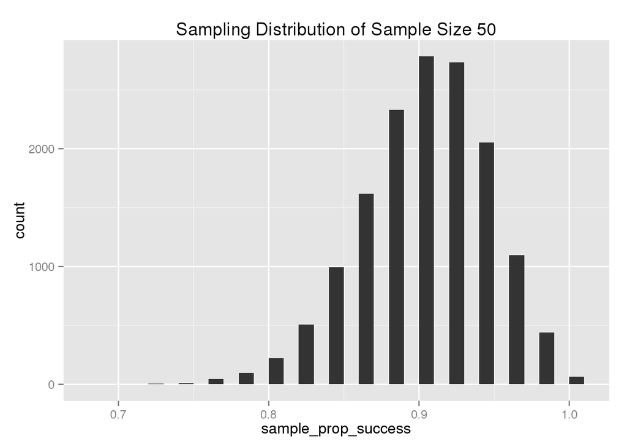

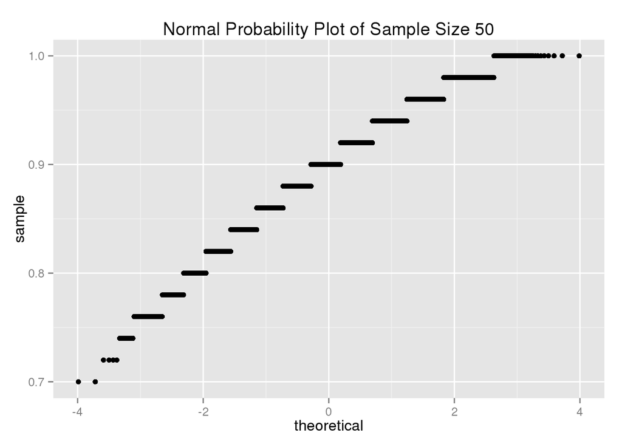

```
##        mean median        sd
## 1 0.8993147    0.9 0.0424738
```

```r
sampling(data = pops$p_high, nsample = 200, seed = 2917, n_sim = 15000, success = "success")
```

```
## stat_bin: binwidth defaulted to range/30. Use 'binwidth = x' to adjust this.
```

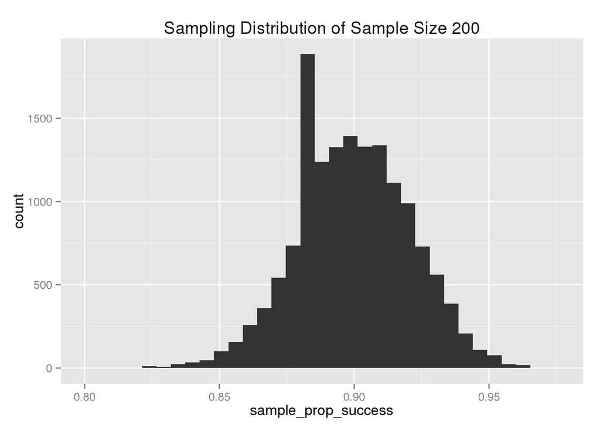

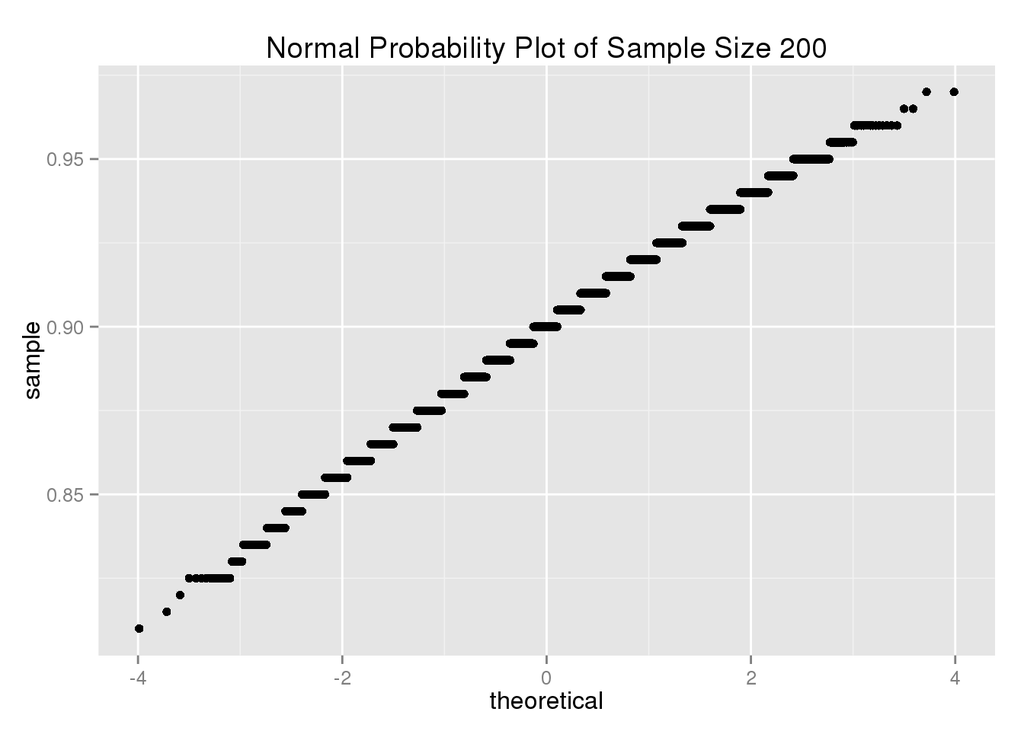

```
##       mean median         sd
## 1 0.899704    0.9 0.02115433
```

As expected, both the histograms of the sampling distributions and the Normal Probability Plots of all four data sets show that as sample size increases, the data becomes closer to a Normal distribution. The sample distribution curves start to look more similar to a Normal distribution curve and the Normal Probability Plots look more linear. This trend is particularly more noticeable the more skewed the data is (eg. particularly more for the populations with very low probability of success and high probability of success), as the sample distribution cruve and Normal Probability Plot one for the medium probability of success looked pretty close to that of a Normal distribution with even a sample size of 10 whereas the graphs for the two most skewed data didn’t look similar a Normal distribution until the sample size was increased to 200.

In other words, as sample sizes increase, the different populations become more similar because they all become more similar to a Normal distribution. This is due to the Central Limit Theorem, which states that the distribution of of a large number of independent, identically distributed variables will be approximately normal, regardless of the underlying distribution.

**Part 2: Inference**

Loading dataset

```r
gss <- read.csv("https://stat.duke.edu/~mc301/data/gss2010.csv", stringsAsFactors = FALSE)
```

1. Working extra:

m = true mean number of days per month Americans work overtime

$H_0: m = 5$

$H_A: m > 5$

Summary Stats:

```r
moredays_summ <- gss %>%
  filter(!is.na(moredays)) %>%
  summarise(xbar=mean(moredays),sd=sd(moredays),n=length(moredays))

moredays_summ
```

```
##       xbar       sd    n
## 1 5.710549 7.546361 1147
```

Hypothesis Test:

```r
#calculations
standard_error <- moredays_summ$sd/sqrt(moredays_summ$n)
t <- (moredays_summ$xbar-5)/standard_error
df <- moredays_summ$n-1

#p-value
pt(t,df,lower.tail = FALSE)
```

```
## [1] 0.0007334648
```

```r
#P-value from t.test function:
t.test(x = gss$moredays, alternative="greater", mu = 5)
```

```
##
##  One Sample t-test
##
## data:  gss$moredays
## t = 3.1889, df = 1146, p-value = 0.0007335
## alternative hypothesis: true mean is greater than 5
## 95 percent confidence interval:
##  5.343745      Inf
## sample estimates:
## mean of x
##  5.710549
```

Our p-value of 0.000734 is less than our significance level of 0.05; thus, we reject our null hypothesis. We have convincing evidence to suggest that Americans, on average, work overtime more than 5 days per month.

Confidence Interval:

```r
t_star <- qt(0.95, df)
pt_est <- moredays_summ$xbar
round(pt_est + c(-1,1) * t_star * standard_error, 3)
```

```
## [1] 5.344 6.077
```

```r
"Confidence Interval from t.test function:"
```

```
## [1] "Confidence Interval from t.test function:"
```

```r
t.test(x = gss$moredays, conf.level = 0.9)$conf.int
```

```
## [1] 5.343745 6.077353
## attr(,"conf.level")
## [1] 0.9
```

I am 90% confident that the true mean number of days Americans work overtime per month is between 5.344 and 6.078. This is consistent with my Hypothesis Test, as I rejected the null hypothesis; thus, 5, the number stated in my null hypothesis, is not contained in the confidence interval.

2. Working extra and education:

$m_1$: true mean number of days worked by Americans with college education each month

$m_2$: true mean number of days worked by Americans without college education each month

$H_0: m_{1}=m_{2}$

$H_A: m_{1}!=m_{2}$

Mutating Degree variable to make it binary:

```r
gss <- gss %>%
  mutate(degree_recode = ifelse(degree %in% c("Don't know","No answer"),NA,
                                ifelse(degree %in% c("GRADUATE","BACHELOR","JUNIOR COLLEGE"),"college",
                                       ifelse(degree %in% c("HIGH SCHOOL","LT HIGH SCHOOL"),"no college",degree))))
```

Summary statistics:

```r
moredays_education_summ <- gss %>%
  filter(!is.na(moredays)) %>%
  group_by(degree_recode) %>%
  summarise(xbar=mean(moredays), sd = sd(moredays), n = length(moredays))

moredays_education_summ
```

```
## Source: local data frame [2 x 4]
##
##   degree_recode     xbar       sd   n
## 1       college 6.872470 7.977525 494
## 2    no college 4.831547 7.083580 653
```

Calculations:

```r
standard_error <- sqrt((moredays_education_summ$sd[1]^2)/(moredays_education_summ$n[1])+(moredays_education_summ$sd[2]^2)/(moredays_education_summ$n[2]))
t <- (moredays_education_summ$xbar[1]-moredays_education_summ$xbar[2])/standard_error
df <- min(moredays_education_summ$n[1],moredays_education_summ$n[2])-1
```

Hypothesis Test:

```r
#P-value
#divide p-value by 2 because two-sided test
p_value <- (pt(t,df,lower.tail = FALSE))/2
p_value
```

```
## [1] 2.118525e-06
```

```r
#P-value from t.test function:
t.test(x = gss$moredays, alternative="two.sided", mu = 0)
```

```
##
##  One Sample t-test
##
## data:  gss$moredays
## t = 25.628, df = 1146, p-value < 2.2e-16
## alternative hypothesis: true mean is not equal to 0
## 95 percent confidence interval:
##  5.273367 6.147732
## sample estimates:
## mean of x
##  5.710549
```

Confidence Interval:

```r
t_star <- qt(0.95, df)
pt_est <- moredays_summ$xbar
round(pt_est + c(-1,1) * t_star * standard_error, 3)
```

```
## [1] 4.963 6.458
```

```r
"Confidence Interval from t.test function:"
```

```
## [1] "Confidence Interval from t.test function:"
```

```r
t.test(x = gss$moredays, conf.level = 0.95)$conf.int
```

```
## [1] 5.273367 6.147732
## attr(,"conf.level")
## [1] 0.95
```

3. Life after death

Mutate variable to eliminate “Don’t Answer” and “No Answer”

```r
gss <- gss %>%
  mutate(postlife_recode = ifelse(postlife %in% c("DON'T KNOW","NO ANSWER"),NA,postlife))
```

Summary Stats:

```r
postlife_summ <- gss %>%
  filter(!is.na(postlife_recode)) %>%
  summarise(x=sum(postlife_recode=="YES"),n=length(postlife_recode),p_hat=x/n)

postlife_summ
```

```
##      x    n     p_hat
## 1 1462 1803 0.8108708
```

Confidence interval using CLT:

```r
#calculations
standard_error <- sqrt(postlife_summ$p_hat*(1-postlife_summ$p_hat)/postlife_summ$n)

#Confidence Interval
z_star <- qnorm(0.975)
round(postlife_summ$p_hat + c(-1,1) * z_star * standard_error, 3)
```

```
## [1] 0.793 0.829
```

```r
"Confidence Interval from t.test function:"
```

```
## [1] "Confidence Interval from t.test function:"
```

```r
prop.test(postlife_summ$x, postlife_summ$n, conf.level = 0.95, correct = FALSE)$conf.int
```

```
## [1] 0.7921408 0.8282788
## attr(,"conf.level")
## [1] 0.95
```

```r
set.seed(4958347)
nsim = 15000
postlife_dist = data.frame(stat = rep(NA, nsim))

for(i in 1:nsim) {
  postlife_sample = sample(gss$postlife_recode, size = 200, replace = TRUE)
  postlife_dist$stat[i] = sum(postlife_sample == "YES")/200
}

stat = sum(gss$postlife == "YES") / postlife_summ$n
se_boot = sd(postlife_dist$stat)
boot_int = round(stat + c(-1,1) * 1.96 * se_boot, 3)

boot_int
```

```
## [1] NA NA
```

4. Pick your own

Question: Is the proportion of Americans who are satisfied with their financial status different greater if they were born in the US than if they were not?

$p_{US_born} = true proportion of US-born Americans who are satisfied with their financial status$

$p_{not_US_born} = true proportion of non-US-born Americans who are satisfied with their financial status$

$H_0: p_{US_born} - p_{not_US_born} = 0$

$H_A: p_{US_born} - p_{not_US_born} > 0$

Mutating variables to make them binary:

```r
gss <- gss %>%
  mutate(born_recode = ifelse(born %in% c("NO ANSWER","NOT APPLICABLE","DON'T KNOW"),NA,born))

gss <- gss %>%
  mutate(satfin_recode = ifelse(satfin %in% c("DON'T KNOW", "NO ANSWER", "MORE OR LESS"),NA,
                               ifelse(satfin == "SATISFIED","satisfied",
                                      ifelse(satfin == "NOT AT ALL SAT", "not satisfied",satfin))))
```

Summary statistics:

```r
satfin_born_summ <- gss %>%
  filter(!is.na(born_recode)) %>%
  filter(!is.na(satfin_recode)) %>%
  group_by(born_recode) %>%
  summarise(x=sum(satfin_recode=="satisfied"),n=length(satfin_recode),p_hat=x/n)

satfin_born_summ
```

```
## Source: local data frame [2 x 4]
##
##   born_recode   x   n     p_hat
## 1          NO  49 126 0.3888889
## 2         YES 429 994 0.4315895
```

Hypothesis Test:

```r
#Pooled proportion

total_satisfied <- sum(satfin_born_summ$x)
total_n <- sum(satfin_born_summ$n)
p_pool <- total_satisfied / total_n

p_pool
```

```
## [1] 0.4267857
```

```r
#Calculating test statistic

se <- sqrt(p_pool * (1-p_pool)/satfin_born_summ$n[2] + p_pool * (1-p_pool)/satfin_born_summ$n[1])
z <- (satfin_born_summ$p_hat[2] - satfin_born_summ$p_hat[1] - 0 / se)
z
```

```
## [1] 0.04270065
```

```r
#p-value
pnorm(z,lower.tail=FALSE)
```

```
## [1] 0.4829701
```

My p-value of 0.483 is greater than my significance level of 0.05; thus, we fail to reject the null hypothesis. There is not convincing evidence to suggest that there is a difference in proportion of people who are satisifed with their financial situation based on whether or not they were born in the US or not.

Confidence Interval:

```r
se <- sqrt((satfin_born_summ$p_hat[2] * (1-satfin_born_summ$p_hat[2])/satfin_born_summ$n[2]) + (satfin_born_summ$p_hat[1] * (1-satfin_born_summ$p_hat[1])/satfin_born_summ$n[1]))
z_star <- qnorm(0.975)
pt_est <- satfin_born_summ$p_hat[2] - satfin_born_summ$p_hat[1]
round(pt_est + c(-1,1) * z_star * se, 3)
```

```
## [1] -0.048  0.133
```

```r
"Confidence Interval from t.test function:"
```

```
## [1] "Confidence Interval from t.test function:"
```

```r
prop.test(x = c(satfin_born_summ$x[2], satfin_born_summ$x[1]), n = c(satfin_born_summ$n[2], satfin_born_summ$n[1]),conf.level = 0.95, correct = FALSE)$conf.int
```

```
## [1] -0.0478180  0.1332193
## attr(,"conf.level")
## [1] 0.95
```

I am 95% confident that the true difference in proportion of people who are born in the US and satisfied with their financial situation and people who are not born in the US and satisfied with their financial situation is between -0.048 and 0.133. This interval includes 0, the value in our null hypothesis, which makes sense since we failed to reject our null hypothesis in the hypothesis test.

**Part 3: Extra Credit**

Loading data

```r
zinc <- read.csv("https://stat.duke.edu/~mc301/data/zinc.csv", stringsAsFactors = FALSE)
```

Hypothesis Testing using 5% signficance level:

$m_1$ = zinc concentration in bottom water

$m_2$ = zinc concentration in surface water

$H_0: m_1 - m_2 = 0$

$H_A: m_1 - m_2 > 0$

Create new variable diff = zinc concentration in bottom water - zinc concentration in surface water

```r
diff <- zinc$bottom - zinc$surface
```

Summary Statistics for diff:

```r
diff_summ <- zinc %>%
  summarise(xbar=mean(diff),sd=sd(diff),n=length(diff))

diff_summ
```

```
##     xbar         sd  n
## 1 0.0804 0.05227321 10
```

Hypothesis Test:

```r
#calculations
standard_error <- diff_summ$sd/sqrt(diff_summ$n)
t <- (diff_summ$xbar-0)/standard_error
df <- diff_summ$n-1

#p-value
p_value <- (pt(t,df,lower.tail = FALSE))
p_value
```

```
## [1] 0.0004455577
```

```r
"P-value from t.test function:"
```

```
## [1] "P-value from t.test function:"
```

```r
t.test(x = zinc$bottom, y = zinc$surface, alternative="greater", paired = TRUE, mu = 0)
```

```
##
##  Paired t-test
##
## data:  zinc$bottom and zinc$surface
## t = 4.8638, df = 9, p-value = 0.0004456
## alternative hypothesis: true difference in means is greater than 0
## 95 percent confidence interval:
##  0.0500982       Inf
## sample estimates:
## mean of the differences
##                  0.0804
```

My p-value of 0.000446 is less than our significance level of 0.05; thus, we reject our null hypothesis. There is convincing evidence to suggest that the concentration of trace metals in bottom water is greater than the concentration in surface water.